# Creating the Player’s Main Building

In a tower defense game, there needs to be something to defend. Usually, players protect a central building while enemies move towards it to damage it.

The destruction of this building triggers the game’s loss condition. Defending it successfully leads to the game’s win condition.

In this lesson we’ll create the player’s base and learn to:

- Handle damage notifications
- Trigger health depletion
- Manage death events

The main building will use the *HurtBoxArea2D* we created previously. It also uses a *SelectableArea2D* to toggle a health bar. This is how it relates to other classes:

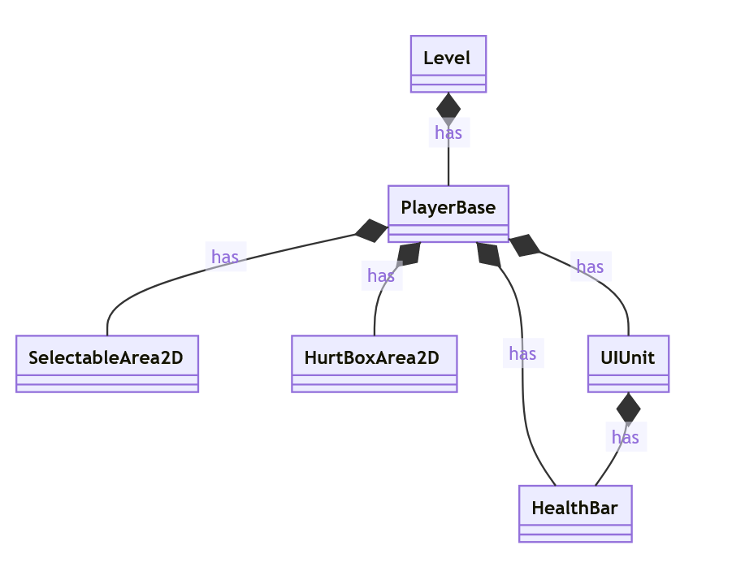

## Setting up the PlayerBase

We use a *Node2D* as the root for our scene and name it *PlayerBase*. You can save the scene as `res://Objects/PlayerBase/PlayerBase.tscn`.

The *PlayerBase*’s graphics are a bit more complex and have some animations. We’ve decided to provide them beforehand to save you time. They’re available at `res://Objects/PlayerBase/CutoutPlayerBase.tscn`. Create an instance of the `CutoutPlayerBase.tscn` as a child of the *PlayerBase* and rename it as *Sprites*.

Instance a *HurtBoxArea2D* so *HitBoxArea2Ds* that aren’t on the player’s team can hurt the *PlayerBase*.

The *HurtBoxArea2D* needs a *CollisionShape2D* and a *Shape2D* so add them as a child of the *HurtBoxArea2D*. Use a *RectangleShape2D* that encloses the *Sprites*.

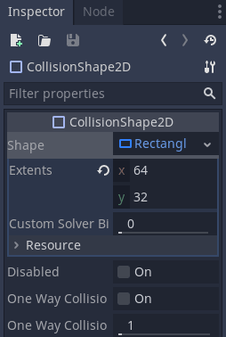

The main responsibility of the *PlayerBase* is to keep track of its health amount and notify other objects.

We have two health bars for two different purposes. One will show itself when the player selects the base during the tower placement phase. The other will flash when the base gets damaged during play.

Like with the tower, we use the `res://UI/UIUnit/UIUnit.tscn` scene to animate the health bar. Add it to the scene and instance the *HealthBar* as a child of the *Interface*.

We use the *SelectableArea2D* we’ve created for in the *Towers* chapter to allow players to click on the *PlayerBase* and display its *Interface*.

Duplicate the *HurtBoxArea2D*’s *CollisionShape2D* and reparent it as a child of the *SelectableArea2D*. Delete the indexing character at the end. Its name should be *CollisionShape2D*.

In the same folder you’ve found the *HealthBar*, there’s a `TimedHealthBar.tscn` file. This is a *HealthBar* that shows itself when its values change and hides itself after some time. Instance it as a child of the *PlayerBase*.

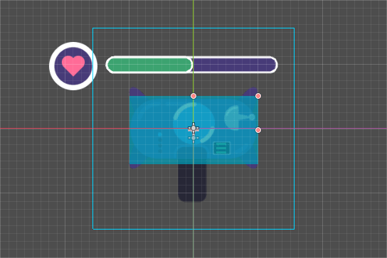

This is how the *PlayerBase*’s scene should look like after this setup.

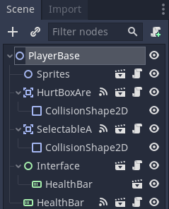

## Handling health and damage

The *PlayerBase* needs health management logic that takes into account its max and current health. The `max_health` is an exported variable to allow us to set the *PlayerBase*’s health through the inspector. The `health` represents the current health amount. We encapsulate `health` into a `set_health` setter method so we can clamp its value. We create a `destroyed` signal to notify other objects it has no health left.

We initialize the `health` in the `_ready()` callback to ensure it always starts with the same value as the `max_health`.

```
extends Node2D

signal destroyed

export var max_health := 10
var health := max_health setget set_health

func _ready() -> void:
    health = max_health
```

For now, we use the `set_health()` to set the `health`. It clamp the `health` so it never goes beyond the maximum health or bellow zero.

```
func set_health(value: int) -> void:
    health = clamp(value, 0, max_health)
```

Connect the *HurtBoxArea2D*’s `hit_landed` signal to the *PlayerBase*’s script so we can damage the *PlayerBase*.

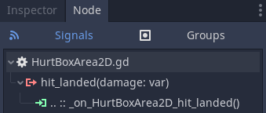

We call the `set_health()` method inside the `_on_HurtBoxArea2D_hit_landed` callback.. We subtract the damage from the current `health` amount.

```
func _on_HurtBoxArea2D_hit_landed(damage: int) -> void:
    set_health(health - damage)
```

## Displaying the health to players

With the damage and health management in place, we need to display the health to players when it changes. Let’s create some reference variables.

```
onready var _sprites := $Sprites
onready var _interface := $Interface
onready var _ui_health_bar := $Interface/HealthBar
onready var _health_bar := $HealthBar
onready var _hurt_box := $HurtBoxArea2D
```

We have two interface elements that should always display the same data. It can be error-prone if we have to manually ensure that they are always synced.

Godot has a trick for *Ranges* like the *ProgressBars* we’re using for the *HealthBars*. They can share their data with other *Ranges* so they all display the same information using the `share()` method. This allows us to choose one of our *HealthBars* and only work with that.

We chose the `_ui_health_bar` to be the main *HealthBar*.

After that we can set the `_ui_health_bar.max_value` and `value` to be the *PlayerBase*’s `max_health` and `health`.

```
func _ready() -> void:
    health = max_health

    _ui_health_bar.share(_health_bar)
    _ui_health_bar.max_value = max_health
    _ui_health_bar.value = health
```

We use the `set_health()` setter to update the *HealthBars* when the `health` changes, .

```
func set_health(value: int) -> void:
    health = clamp(value, 0, max_health)

    _ui_health_bar.value = health
```

Connect the *SelectableArea2D*’s `selection_change` signal to a `_on_SelectableArea2D_selection_changed()` callback to change the health bar visibility during the planning phase.

```
func _on_SelectableArea2D_selection_changed(selected: bool) -> void:
    if selected:
        _interface.appear()
    else:
        _interface.disappear()
```

## Destroying the PlayerBase

The player loses when the *PlayerBase* has zero health. We create a pseudo-private method called `_destroy()`. We call this method inside the `set_health()` setter method after detecting that the `health` is below `1`.

```
func set_health(value: int) -> void:
    health = clamp(value, 0, max_health)
    _ui_health_bar.value = health

    if health < 1:
        _destroy()
```

We emit the `destroyed` signal inside the `_destroy()` method. We also play the `Explode` animations on the `_sprites` node.

Since we won’t remove the *PlayerBase* from the `SceneTree`, we need to avoid triggering its destruction more than once.

We make a deferred call to the *HurtBoxArea2D* to disable its `monitorable` property in the `_destroy()` method. This will prevent it from overlapping with *HitBoxArea2Ds* and stop it from receiving any damage. We can’t change physics properties during a physics frame so we use a deferred call so it happens after the current physics frame.

```
func _destroy() -> void:
    emit_signal("destroyed")
    _sprites.play("Explode")
    _hurt_box.set_deferred("monitorable", false)
```

## Code so far

With all that, we have the following code for the *PlayerBase*.

`PlayerBase.gd`

```
# The Player's main building.
extends Node2D

signal destroyed

export var max_health := 10
var health := max_health setget set_health

onready var _sprites := $Sprites
onready var _interface := $Interface
onready var _ui_health_bar := $Interface/HealthBar
onready var _health_bar := $HealthBar
onready var _hurt_box := $HurtBoxArea2D


func _ready() -> void:
    health = max_health

    # Share the Interface/HealthBar's values with the HealthBar
    # to keep them synced
    _ui_health_bar.share(_health_bar)

    _ui_health_bar.max_value = max_health
    _ui_health_bar.value = health


func set_health(value: int) -> void:
    health = clamp(value, 0, max_health)

    _ui_health_bar.value = health

    if health < 1:
        _destroy()


func _destroy() -> void:
    emit_signal("destroyed")
    _sprites.play("Explode")

    # Make a deferred call to prevent errors
    _hurt_box.set_deferred("monitorable", false)


func _on_HurtBoxArea2D_hit_landed(damage: int) -> void:
    set_health(health - damage)


func _on_SelectableArea2D_selection_changed(selected: bool) -> void:
    if selected:
        _interface.appear()
    else:
        _interface.disappear()
```

## Testing the PlayerBase

To test the *PlayerBase*, move it to the middle of the scene and test the scene. You can press F6 for that.

Click on the *PlayerBase* to select it. It should display the *HealthBar* that’s a child of the *Interface*.

Go to the *Remote SceneTree* tab and click on the *PlayerBase* node. Decrease its *Health* until it reaches `0` using the *Inspector*. The other *HealthBar* should appear as we decrease the value. When it reaches `0`, the *PlayerBase* explodes, as expected.

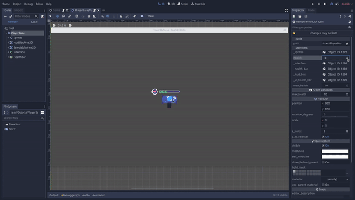